# УЧЕБНИК ДЛЯ ВУЗОВ

# Пример применения функции:

```
vector <int> v;
v.reserve(1000); // Выделение памяти под 1000 элементов
```

После выполнения этой функции значение функции `capacity` будет равно `n` леньшей мере `n`. Функцию `reserve` полезно применять тогда, когда размер вектора известен заранее. Для изменения размеров вектора служит функция resize:

```
void resize(size_type sz, T c= T() );
```

Эта функция увеличивает или уменьшает размер вектора в зависимости от того, больше задаваемое значение `sz`, чем значение `size()`, или меньше. Второй параметр задает значение, которое присваивается всем новым элементам вектора. Они помещаются в конец вектора. Если новый размер меньше, чем значение `size()`, из конца вектора удаляется `size()` - `sz` элементов. Определены следующие методы для изменения объектов класса `vector`:

```
void push_back (const T& value);
void pop_back ();
iterator insert(iterator position, const T& value);
void insert(iterator position, size_type n, const T& value);
template <class InputIter>
    void insert(iterator position, InputIter first. InputIter last);
iterator erase(iterator position);
iterator erase(iterator first, iterator last);
void swap();
void clear(); // Очистка вектора
```

Функция `push_back` добавляет элемент в конец вектора, функция `pop_back` — удаляет элемент из конца вектора. Функция `insert` служит для вставки элемента в вектор. Первая форма функции вставляет элемент value в позицию, заданную первым параметром (итератором), и возвращает итератор, ссылающийся на вставленный элемент. Вторая форма функции вставляет в вектор `n` одинаковых элементов. Третья форма функции позволяет вставить несколько элементов, которые могут быть заданы любым диапазоном элементов подходящего типа, например:

```
vector <int> v(2), v1(3.9);
int m[3] = (3,4,5};
v.insert(v.begin(),m, m + 3); // Содержимое v: 3 4 5 0 0
v1.insert(v1.begin() + 1, v.begin().v.begin() + 2);
// Содержимое v1: 9 3 4 9 9
```

Вставка в вектор занимает время, пропорциональное количеству сдвигаемых на новые позиции элементов. При этом, если новый размер вектора превышает объем занимаемой памяти, происходит перераспределение памяти. Это - плата за легкость доступа по индексу. Если при вставке перераспределения не происходит, все итераторы сохраняют свои значения. В противном случае они становятся недействительными.

Страница 303

Функция `erase` служит для удаления одного элемента вектора (первая форма функции) или диапазона, заданного с помощью итераторов (вторая форма):

```
vector <int> v;
for (int i = 1; i<6; i++)
    v.push_back(i);
    // Содержимое V: 12345
    v.erase(v.begin()); // Содержимое v: 2 3 4 5
    v.erase(v.begin(), v.begin() + 2); // Содержимое v: 4 5
```

Обратите внимание, что третьим параметром задается не последний удаляемый элемент, а элемент, следующий за ним. Каждый вызов функции `erase` так же, как и в случае вставки, занимает время, пропорциональное количеству сдвигаемых на новые позиции элементов. Все итераторы и ссылки «правее» места удаления становятся недействительными. Функция `swap` служит для обмена элементов двух векторов одного типа, но обязательно одного размера:

```
vector <int> vl, v2;
vl.swap(v2); // Эквивалентно v2.swap(v1);
```

Для векторов определены **операции сравнения** `=`, `!=`, `<`, `<=` и `=`. Два вектора считаются равными, если равны их размеры и все соответствующие пары элементов. Один вектор меньше другого, если первый из элементов одного вектора, не равй соответствующему элементу другого, меньше него (то есть сравнение лексикографическое).

**Пример**:

```
#include <vector>
using namespace std;
vector <int> v7, v8;
int main()
{
    for (int i = 0; i<6; i++)
        v7.push_back(i);
    cout << "v7: ";
    for (int i = 0; i<6; i++)
        cout << v7[i] << " ";
    coút << endl;
    for (int i = 0; i<3; i++)
        V8.push_back(i+1);
    cout << "v8:";
    for (int i = 0; 1<3; i++)
        cout << v8[i] << " ";
    cout << endl;
    if (v7 < v8)
    { cout << " u7 < v8" << endl; }
    else { cout << " v7 > v8" << endl;}
}
```

Результат работы программы:

```
v7: 0 1 2 3 4 5
v8: 1 2 3
v7 < v8
```

Для эффективной работы с векторами в стандартной библиотеке определены шаблоны функций, называемые алгоритмами. Они включают в себя поиск значений, сортировку элементов, вставку, замену, удаление и другие операции. Алгоритмы описаны в разделе «Алгоритмы» на с. 343.

Страница 304

# Векторы логических значений `(vector <bool>)`

Специализация шаблона `vector<bool>` определена для оптимизации размещения памяти, поскольку можно реализовать вектор логических значений так, чтобы его элемент занимал 1 бит. При этом адресация отдельных битов выполняется программно. Итератор такого вектора не может быть указателем. В остальном векторы логических значений аналогичны обычным и реализуют тот же набор операций и методов. В дополнение к ним определены методы инвертирования бита и вектора в целом `(flip)`. Ссылка на элемент вектора логических значений реализована в виде класса `reference`, моделирующего обычную ссылку на элемент:

```
class reference
{
        friend class vector;
        reference();
    public:
        -reference();
        operator bool() const;
        reference& operator=(const bool x);
        reference& operator=(const reference& x);
        void flip();
};
```

Пример (с клавиатуры вводятся в вектор 10 значений 0 или 1, после чего они выводятся на экран).

```
#include <vector>
#include <iostream>
using namespace std;
vector <bool> v (10);
int main()
{
    for (int i = 0; i < v.size(); i++)
        cin >> v[i];
    for (vector<bool>:: const_iterator p = v.begin(); p!=v.end(); ++p)
        cout << *p;
}
```

Страница 305

# Двусторонние очереди `(deque)`

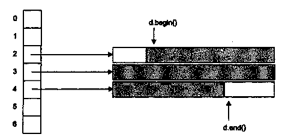

Рис. 12.1. Организация двусторонней очереди

Для создания двусторонней очереди можно воспользоваться следующими конструкторами (приведена упрощенная запись), аналогичными конструкторам вектора:

```
explicit deque(); // 1
explicit deque(size_type n, const T& value = T()); // 2
template <class InputIter> // 3
    deque(InputIter first, InputIter last);
deque(const vector<T>& x); // 4
```

- **Конструктор 1** является конструктором по умолчанию.
- **Конструктор 2** создает очередь длиной `n` и заполняет ее одинаковыми элементами — копиями `value`.
- **Конструктор 3** создает очередь путем копирования указанного с помощью итераторов диапазона элементов. Тип итераторов должен быть «для чтения».
- **Конструктор 4** является конструктором копирования.

# Примеры конструкторов:

```
// Создается очередь из 10 равных единице элементов:
deque<int> d2 (10, 1);
// Создается очередь, равная очереди v1:
deque <int> d4 (v1);
// Создается очередь из двух элементов, равных первым двум
// элементам вектора v1 из предыдущего раздела:
deque <int> d3 (v1.begin(), v1.begin() + 2);
// Создается очередь из 10 объектов класса monstr (см. с. 183)
// (работает конструктор по умолчанию) :
deque <monstr> m1 (10);
// Создается очередь из 5 объектов класса monstr с заданным именем
// (работает конструктор с параметром char*) :
deque <monstr> m2 (5, monstr("Вася в очереди"));
```

Страница 306

В шаблоне `deque` определены операция **присваивания**, функция **копирования**, **итераторы**, **операции сравнения**, операции и функции **доступа к элементам** и **изменения объектов**, аналогичные соответствующим операциям и функциям вектора. Вставка и удаление так же, как и для вектора, выполняются за пропорциональное количеству элементов время. Если эти операции выполняются над внутренними элементами очереди, все значения итераторов и ссылок на элементы очереди становятся недействительными. После операций добавления в любой из концов все значения итераторов становятся недействительными, а значения ссылок на элементы очереди сохраняются. После операций выборки из любого конца становятся недействительными только значения итераторов и ссылок, связанных с этими элементами. Кроме перечисленных, определены функции **добавления и выборки из начала очереди**:

```
void push_front(const T& value);
void pop_front();
```

При выборке элемент удаляется из очереди. Для очереди не определены функции `capacity` и `reserve`, но есть функции `resize` и `size`. К очередям можно применять алгоритмы стандартной библиотеки, описанные в главе 14 «Алгоритмы» на с. 343.

# Списки `(list)`

Список не предоставляет произвольного доступа к своим элементам, зато вставка и удаление выполняются за постоянное время. Класс `list` реализован в `STL` в виде двусвязного списка, каждый узел которого содержит ссылки на последующий и предыдущий элементы. Поэтому операции инкремента и декремента для итераторов списка выполняются за пюстоянное время, а передвижение на `n` узлов требует времени, пропорционального `n`. После выполнения операций вставки и удаления значения всех итераторов и ссылок остаются действительными. Список поддерживает **конструкторы**, операцию **присваивания**, функцию **копирования**, операции **сравнения** и **итераторы**, аналогичные **векторам** и **очередям**. **Доступ к элементам** для списков ограничивается следующими методами:

```
reference front ();
const_reference front() const;
reference back();
const _reference back() const;
```

Для занесения в начало и конец списка определены методы, аналогичные соответствующим методам очереди:

```
void push_front(const T& value);
void pop_front();
void push_back(const T& value);
void pop_back();
```

Страница 307

Кроме того, действуют все остальные методы для изменения объектов `list`, аналогичные векторам и очередям:

```
iterator insert(iterator position, const T& value);
void insert(iterator position, size_type n, const T& value);
template <class InputIter>
    void insert(iterator position, Inputiter first, InputIter last);
iterator erase(iterator position);
iterator erase(iterator first, iterator last);
void swap();
void clear();
```

Для списка не определена функция `сарасіty`, поскольку память под элементы отводится по мере необходимости. Можно изменить размер списка, удалив или довив элементы в конец списка (аналогично двусторонней очереди):

```
void resize(size_type sz, T c = T());
```

Кроме перечисленных, для списков определено несколько специфических методов. Сцепка списков `(splice)` служит для перемещения элементов из одного списка в другой без перераспределения памяти, только за счет изменения указателей:

```
void splice(iterator position, list<T>& x);
void splice(iterator position, list<T>& x, iterator i);
void splice(iterator position, list<T>& X, iterator first, iterator last);
```

Оба списка должны содержать элементы одного типа. Первая форма функции вставляет в вызывающий список перед элементом, позиция которого указана первым параметром, все элементы списка, указанного вторым параметром, например:

```
list <int> L1, L2;
// ... // Формирование списков
L1.splice(L1.begin() + 4, L2);
```

**Второй список** остается пустым. Нельзя вставить список в самого себя.

**Вторая форма** функции переносит элемент, позицию которого определяет третий параметр, из списка `х` в вызывающий список. Допускается переносить элемент в пределах одного списка.

**Третья форма** функции аналогичным образом переносит из списка в список несколько элементов. Их диапазон задается третьим и четвертым параметрами функции. Если для одного и того же списка первый параметр находится в диапазоне между третьим и четвертым, результат не определен.

Страница 308

**Пример**:

```
#include <list>
using namespace std;
int main()
{
    list<int> L1;
    list<int>::iterator i, j, k;
    for (int i = 0; i<5: i++)
        L1.push_back(i + 1);
    for (int i = 12; i<14; i++)
        L1.push_back(i);
    cout << "Исходный список: ";
    for (i = L1.begin(); i != L1.end(); ++i)
        cout << *j << "";
    cout << endl;
    i = L1.begin();
    i++;
    k = L1.end();
    j= --K;
    k++;
    j--;
    L1.splice(i, L1, j, k);
    cout << "Список после сцепки: ";
    for ( i = L1.begin(); i != L1.end(); ++i)
        cout << *i << " ";
}
```

Результат работы программы:

```
Исходный список: 1 2 3 4 5 12 13
Список после сцепки: 1 12 13 2 3 4 5
```

```
void remove(const T& value);
```

Если элементов со значением `value` в списке несколько, все они будут удалены. Можно удалить из списка элементы, удовлетворяющие некоторому условию. Для этого используется функция `remove_if`:

```
template <class Predicate> void remove_if(Predicate pred);
```

Параметром является класс-предикат, задающий условие, накладываемое на элемент списка. О предикатах см. с. 336. Для упорядочивания элементов списка используется метод `sort`:

```
void sort();
template <class Compare> void sort(Compare comp);
```

В первом случае список сортируется по возрастанию элементов (в соответствии с определением операции < для элементов), во втором - в соответствии с функциональным объектом Compare ( функциональных объектах рассказывалось в разделе «Перегрузка операции вызова функции» на с. 195). Функциональный объект имеет значение true, если два передаваемых ему значения должны при сортировке остаться в прежнем порядке, и `false` - в противном случае. Порядок следования элементов, имеющих одинаковые значения, сохраняется. Время сортировки пропорционально $N*log_2N$, где `N` - количество элементов в списке. Метод `unique` оставляет в списке только первый элемент из каждой серии идущих подряд одинаковых элементов. Первая форма метода имеет следующий формат: `void unique();`

Страница 309

Вторая форма метода `unique` использует в качестве параметра бинарный предикат (см. с. 336), что позволяет задать собственный критерий удаления элементов списка. Предикат имеет значение true, если критерий соблюден, и false — в противном случае. Аргументы предиката имеют тип элементов списка:

```
template <class BinaryPredicate>
void unique (BinaryPredicate binary_pred);
```

Для **слияния списков** служит метод `merge`:

```
void merge(list<T>& x);
template <class Compare> void merge(list<T>& x, Compare comp);
```

Оба списка должны быть упорядочены (в первом случае в соответствии с определением операции `<` для элементов, во втором - в соответствии с функциональным объектом `Compare`). Результат - упорядоченный список. Если элементы в вызывающем списке и в списке-параметре совпадают, первыми будут располагаться элементы из вызывающего списка. Метод reverse служит для изменения порядка следования элементов списка на обратный (время работы пропорционально количеству элементов): `void reverse();`

Пример работы со списком:

```
#include <fstream>
#include <list>
using namespace std;
void show (const char *str, const list<int> &L)
{
    cout << str << ":" << endl;
    for (list<int>::const_iterator i = L.begin(); i != L.end(); ++i)
        cout << i << " ";
    cout << endl;
}
```

```
int main()
{
    list<int> L;
    list<int>::iterator i;
    int x;
    ifstream in("inpnum");
    while (in >> x, !in.eof()) L.push_back(x);
    show("Исходный список", L);
        L.push_front(1);
    i = L.begin();
    L.insert(++i, 2);
    show( "После вставки 1 и 2 в начало", L);
    i = L.end();
    L.insert(--i. 100);
    show( "После вставки 100 перед последним", L);
    i = L.begin(); x= *i; L.pop_front();
    cout << "Удалили из начала" << x << endl;
    i = L.end();
    x=*--i;
    L.pop_back();
    cout << "Удалили с конца" << x << endl;
    show( "Список после удаления", L);
    L.remove(76);
    show( "После удаления элементов со значением 76", 4);
    L.sort();
    show ( "После сортировки", L);
    L.unique();
    show("После unique", L);
    list<int> L1(L);
    L.reverse();
    show("После reverse", L);
}
```

Страница 310

Результат работы программы:

```
Исходный список:
56 34 54 0 76 23 51 11 51 11 76 88
После вставки 1 и 2 в начало:
1 2 56 34 54 0 76 23 51 11 51 11 76 88
После вставки 100 перед последним:
1 2 56 34 54 0 76 23 51 11 51 11 76 100 88
Удалили из начала 1
Удалили с конца 88
Список после удаления:
2 56 34 54 0 76 23 51 11 51 11 76 100
После удаления элементов со значением 76:
2 56 34 54 0 23 51 11 51 11 100
После сортировки:
0 2 11 11 23 34 51 51 54 56 100
После unique:
0 2 11 23 34 51 54 56 100
После reverse:
100 56 54 51 34 23 11 2 0
```

К спискам можно применять алгоритмы стандартной библиотеки, описанные в разделе «Алгоритмы» (с. 343).

# Стеки (stack)

Как известно, в стеке (определение см. раздел «Стеки», с. 119) допускаются только две операции, изменяющие его размер - добавление элемента в вершину стека и выборка из вершины. Стек можно реализовать на основе любого из рассмотренных контейнеров: вектора, двусторонней очереди или списка. Таким образом, стек является не новым типом контейнера, а вариантом имеющихся, поэтому он называется адаптером контейнера. Другие адаптеры (очереди и очереди с приоритетами) будут рассмотрены в следующих разделах. B `STL` стек определен по умолчанию на базе двусторонней очереди:

```
template <class T, class Container = deque<T> >
class stack
{
    protected:
        Container c:
    public:
        explicit stack(const Container& = Container());
        bool empty () const {return c. empty(); }
        size_type size() const {return c.size(); }
        value_type& top() { return c.back(); }
        const value_type& top() const {return c.back(); }
        void push(const value_type& x) {c.push_back(x); }
        void pop () {c.pop_back(); )
};
```

Страница 310

Из приведенного описания (оно дано с сокращениями) видно, что метод занесения в стек push соответствует методу занесения в конец push_back, метод выборки из стека pop — методу выборки с конца pop_back, кроме того, добавлен метод top для получения или изменения значения элемента на вершине стека. Конструктору класса stack передается в качестве параметра ссылка на базовый контейнер, который копируется в защищенное поле данных с. При работе со стеком нельзя пользоваться итераторами и нельзя получить значение элемента из середины стека иначе, чем выбрав из него все элементы, лежащие выше. Для стека, как и для всех рассмотренных выше контейнеров, определены операции сравнения (см. 303). Пример использования стека (программа вводит из файла числа и выводит их на экран в обратном порядке):

```
#include <fstream>
#include <vector>
#include <stack>
using namespace std;
int main()
{
    ifstream in ("inpnum");
    stack <int, vector<int>> s;
    int x;
    while (in >> x, !in.eof()) s.push(x);
    while (! s.empty())
    {
        x = s.top();
        cout << x << "";
        s.pop();
    }
}
```

Содержимое файла `inpnum`:

```
56 34 54 0 76 23 51 11 51 11 76 88
```

Результат работы программы:

```
88 76 11 51 11 51 23 76 0 54 34 56
```

Страница 312

# Очереди (queue)

Для очереди (определение см. раздел «Очереди», с. 121) допускаются две операции, изменяющие ее размер - добавление элемента в конец и выборка из начала. Очередь является адаптером, который можно реализовать на основе двусторонней очереди или списка (вектор не подходит, поскольку в нем нет операции выборки из начала). B `STL` очередь определена по умолчанию на базе двусторонней очереди:

```
template <class T, class Container = deque<t>>
class queue
{
    protected:
        Container c;
    public:
        explicit queue(const Container& = Container());
        bool empty() const { return c.empty(); }
        size_type size() const{ return c.size(); )
        value_type& front() { return c.front(); }
        const value_type& front() const { return c.front(); }
        value_typed back() { return c.back (); }
        const value_type& back() const { return c.back(); }
        void push(const value_type& x) { c.push_back(x); }
        void pop() { c.pop _front(); }
};
```

Методы `front` и `back` используются для получения значений элементов, находящихся соответственно в начале и в конце очереди (при этом элементы остаются в очереди).

Пример работы с очередью (программа вводит из файла числа в очередь и выполняет выборку из нее, пока очередь не опустеет):

```
#include <fstream>
#include <list>
#include <queue>
using namespace std;
int main()
{
    ifstream in ("inpnum");
    queue <int, list<int> > q;
    int X;
    while (in >> x. !in.eof())
        q.push(x);
    cout << "q.front();" << q.front() «" ";
    cout << "q.back();" << q.back() << endl;
    while (! q.empty())
    {
        q.pop();
        cout << "q.front(); " << q.front() <<  " ";
        cout << "q.back(): " << q.back() << endl;
    }
}
```

Содержимое файла іпрпит:

```
56 34 54 0 76 23 51 11 51 11 76 88
```

Результат работы программы:

```
q.front(); 56 q.back(); 88
q.front(); 34 q.back(); 88
q.front(); 54 q.back(); 88
q.front(); 0  q.back(); 88
q.front(); 76 q.back(); 88
q.front(); 23 q.back(); 88
q.front(); 51 q.back(); 88
q.front(); 11 q.back(); 88
q.front(); 51 q.back(); 88
q.front(); 11 q.back(); 88
q.front(); 76 q.back(); 88
q.front(); 88 q.back(); 88
q.front(); 0  q.back(); 0
```

К стекам и очередям можно применять алгоритмы стандартной библиотеки, описанные в разделе «Алгоритмы» (с. 343).

Страница 313

# Очереди с приоритетами `(priority_queue)`

В очереди с приоритетами каждому элементу соответствует приоритет, определяющий порядок выборки из очереди. По умолчанию он определяется с помощью операции `<;` таким образом, из очереди каждый раз выбирается максимальный элемент. Для реализации очереди с приоритетами подходит контейнер, допускающий произвольный доступ к элементам, то есть, например, вектор или двусторонняя чередь. Тип контейнера передается вторым параметром шаблона (первый, как обычно, тип элементов). Третьим параметром указывается функция или функциональный объект (см. с. 195 и 334), с помощью которых выполняется определение приоритета:

```
template <class T, class Container = vector<T>,
    class Compare = less<typename Container::value_type> >
class priority_queue
{
    protected:
        Container c;
        Compare comp;
    public:
        explicit priority_queue(
            const Compared x = Compare()
            , const Container& = Container()
        );
    template <class InputIter>
        priority_queue(
            InputIter first
            , Inputiter last
            , const Compare& x = Compare()
            , const Container& = Container()
        );
        bool empty() const { return c.empty(); }
        size_type size() const { return c.size(); }
        const value_type& top() const { return c.front(); }
        void push(const value_type& x);
        void pop();
};
```

Для элементов с равными приоритетами очередь с приоритетами является простой очередью. Как и для стеков, основными методами являются `push`, `рор` и `top`.

Страница 314

Простой пример:

```
#include <iostream>
#include <vector>
#include <functional>
#include <queue>
using namespace std;
int main()
{
    priority_queue <int, vector<int>, less<int> > P;
    int x:
    P.push(13):
    P.push(51):
    P.push(200);
    P.push(17);
    while (!P. empty())
    {
        x = P.top();
        cout << "Выбран элемент: " << x << endl;
        P.pop();
    }
}
```

Результат работы программы:

```
Выбран элемент: 200
Выбран элемент: 51
Выбран элемент: 17
Выбран элемент: 13
```

В этом примере третьим параметром шаблона является шаблон, определенный в заголовочном файле `<functional>` (см. раздел «Функциональные объекты», с. 334). Он задает операцию сравнения на «меньше». Можно задать стандартные шаблоны `greater<тип>`, `greater_equal<тип>`, `less_equal<тип>`. Если требуется определить другой порядок выборки из очереди, вводится собственный функциональный объект. В приведенном ниже примере выборка выполняется по наименьшей сумме цифр в числе:

```
#include <iostream>
#include <vector>
#include <functional>
#include <queue>
using namespace std;
class CompareSum
{
    public:
        bool operator()(int x, int y)
        {
            int sx = 0;
            int sy = 0;
            while (x) { sx +=x % 10; x/=10; }
            while (y) { sy +=y % 10; y/=10; }
            return sx > sy;
         }
};
```

```
int main()
{
    priority_queue <int, vector<int>, CompareSum > P;
    int x;
    P.push(13);
    P.push(51);
    P.push(200);
    P.push(17);
    while(!P.empty())
    {
        x = P.top();
        cout << "Выбран элемент: " << x << endl;
        Р.рор();
    }
}
```

Результат работы программы:

```
Выбран элемент: 200
Выбран элемент: 13
Выбран элемент: 51
Выбран элемент: 17
```

Страница 314

# Ассоциативные контейнеры

Как уже указывалось, ассоциативные контейнеры обеспечивают быстрый доступ к данным за счет того, что опи, как правило, построены на основе сбалансированных деревьев поиска (стандартом регламентируется только интерфейс контейнеров, а не их реализация). Существует пять типов ассоциативных контейнеров: словари (`map`), словари с дубликатами (`multimap`), множества (`set`), множества с дубликатами (`multiset`) и битовые множества (`bitset`). Словари часто называют также ассоциативными массивами или отображениями. Словарь построен на основе пар значений, первое из которых представляет собой ключ для идентификации элемента, а второе - собственно элемент. Можно сказать, что ключ ассоциирован с элементом, откуда и произошло название этих контейнеров. Например, в англо-русском словаре ключом является английское слово, а элементом - русское. Обычный массив тоже можно рассматривать как словарь, ключом в котором служит номер элемента. В словарях, описанных в `STL`, в качестве ключа может использоваться значение произвольного типа. Ассоциативные контейнеры описаны в заголовочных файлах `<map>` и `<set>`. Для хранения пары «ключ-элемент» используется шаблон раг, описанный в заголовочном файле `<utility>`:

```
template <class T1, class T2> struct pair
{
    typedef T1 first_type;
    typedef T2 second_type;
    T1 first;
    T2 second;
    pair();
    pair(const T1& x, const T2& y);
    template <class U, class V> pair(const pair<U,V> &p);
};
```

Страница 316

```
template <class T1, class T2>
    pair<T1, T2> make_pair (const T1& x, const T2& y);
```

Пример формирования пар:

```
#include <iostream>
#include <utility>
using namespace std;
int main()
{
    pair<int, double> p1(10, 12.3), p2(p1);
    p2 = make_pair(20, 12.3); // Эквивалентно p2 = pair <int, double >(20, 12.3)
    cout << "p1: " << p1.first << " " << p1.second << endl;
    cout << "p2: " << p2.first << " " << p2.second << endl;
    p2.first -= 10;
    if (p1 == p2)
        cout << "p1 == p2\n";
    p1.second -= 1;
    if (p2 > p1)
        cout << "p2 > p1\n";
}
```

Результат работы программы:

```
p1: 10 12.3
p2: 20 12.3
p1 == p2
p2 > p1
```

Заголовочный файл `<utility>` при использовании `<map>` или `<set>` подключается автоматически.